# SmithKaartOefening4 slides

Smith Kaart

Oefening 4

Jan Genoe

December 2025

###### Opgave

Gebruik je Smith kaart om een antenne van 150 Ohm aan te passen aan een coax van 50 Ohm voor een frequentie van 600 MHz ($\lambda$= 25 cm; $\epsilon_{r}$=4)? Welke verschillende oplossingen zijn er mogelijk?

###### Smith kaart van de eerste oplossing: C in serie

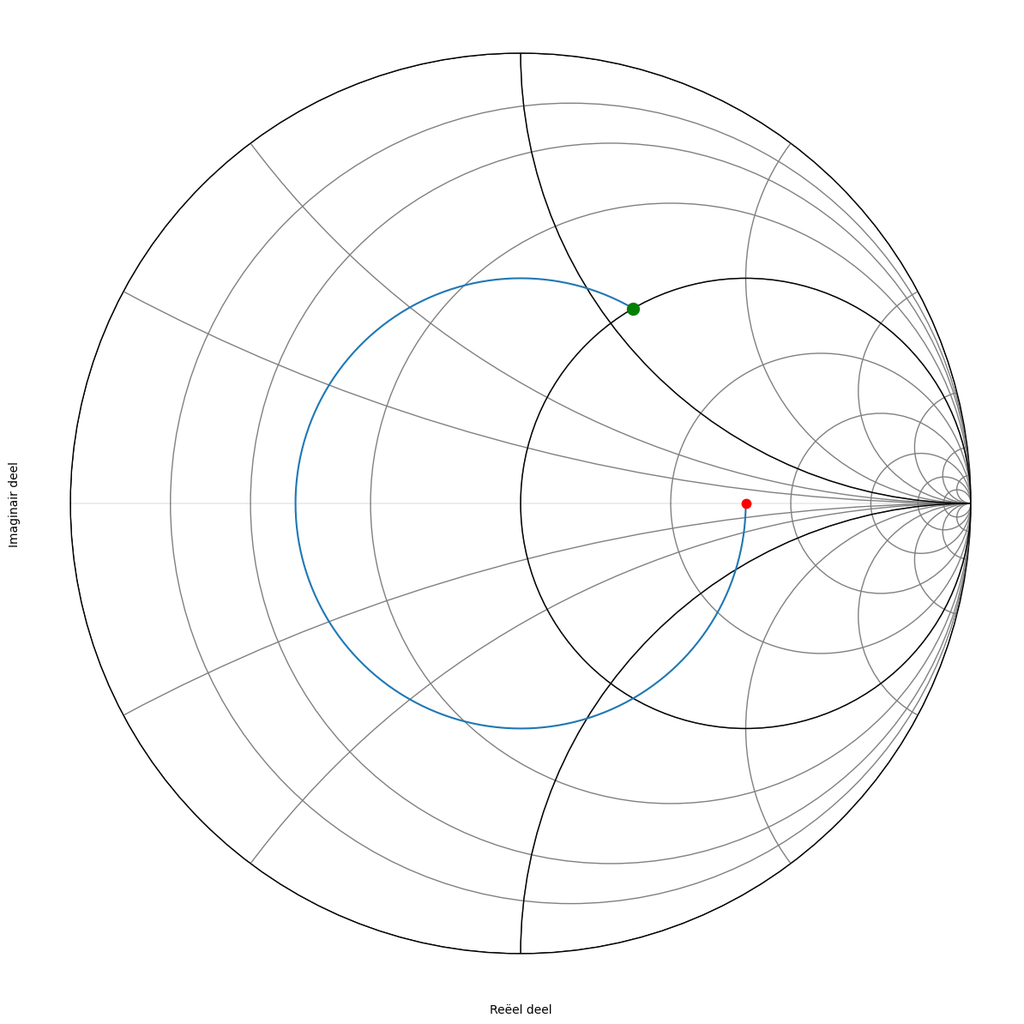

###### detail van het verloop van de impedantie

```
hoek    impedantie (Ohm)     lengte coax (cm)
 297  Z= 47.11+55.97j Ohm     lengte=10.31 cm
 298  Z= 48.04+56.56j Ohm     lengte=10.35 cm
 299  Z= 49.01+57.15j Ohm     lengte=10.38 cm
 300  Z= 50.00+57.74j Ohm     lengte=10.42 cm
 301  Z= 51.02+58.31j Ohm     lengte=10.45 cm
 302  Z= 52.08+58.89j Ohm     lengte=10.49 cm
```

De optimale condensatorwaarde in serie wordt dus 4.59 pF en de nodige lengte van de coax tussen de antenne en de aanpassing is 10.4 cm

Het schema dat we nodig hebben om deze eerst oplossing te realiseren wordt dus:

###### Circuit van de eerste oplossing

[figure not shown]

###### Smith kaart van de tweede oplossing: L in serie

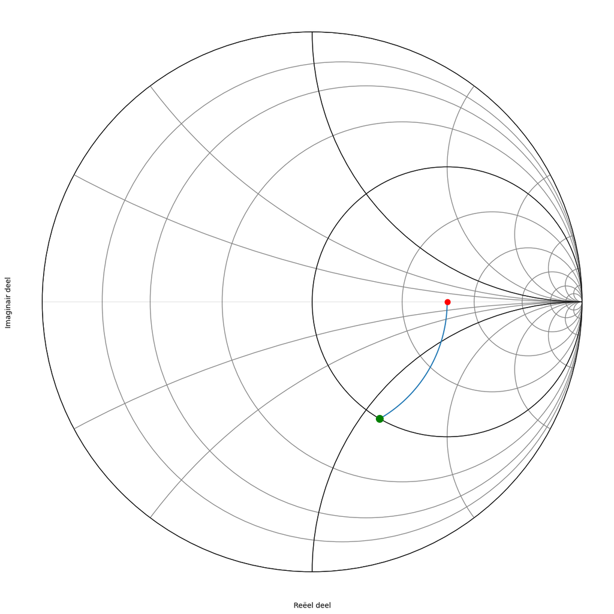

###### detail van het verloop van de impedantie

```
hoek    impedantie (Ohm)     lengte coax (cm)
  57  Z= 53.16-59.45j Ohm     lengte=1.98 cm
  58  Z= 52.08-58.89j Ohm     lengte=2.01 cm
  59  Z= 51.02-58.31j Ohm     lengte=2.05 cm
  60  Z= 50.00-57.74j Ohm     lengte=2.08 cm
  61  Z= 49.01-57.15j Ohm     lengte=2.12 cm
```

[output not shown]

De nieuwe z = 1 - j 1.15. Daaruit volgt dat Z = 50 Ohm - j 57.7 Ohm. Het complexe deel van deze impedantie kunnen we compenseren door een spoel met impedantie van ongeveer j 57.7 Ohm toe te voegen. Als we het helemaal juist willen hebben kunnen we in de array van zlijn juist gaan kijken waar het reële deel 50 Ohm wordt en wat we dan als complex deel over houden.

$$ j \omega L= j 57.7 \Omega$$

$$ \omega= 2 \pi \cdot 600 \times 10^6 $$

$$ L=15 nH $$

Het schema dat we nodig hebben om deze tweede oplossing te realiseren wordt dus:

###### Circuit van de tweede oplossing

[figure not shown]

###### Smith kaart van de derde oplossing: C in parallel

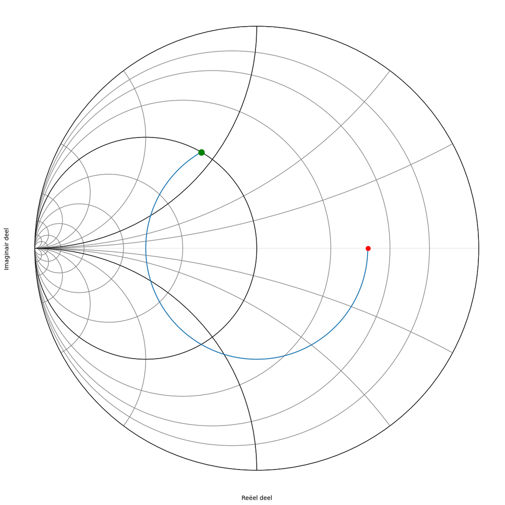

###### Smith kaart van de derde oplossing als admitantie

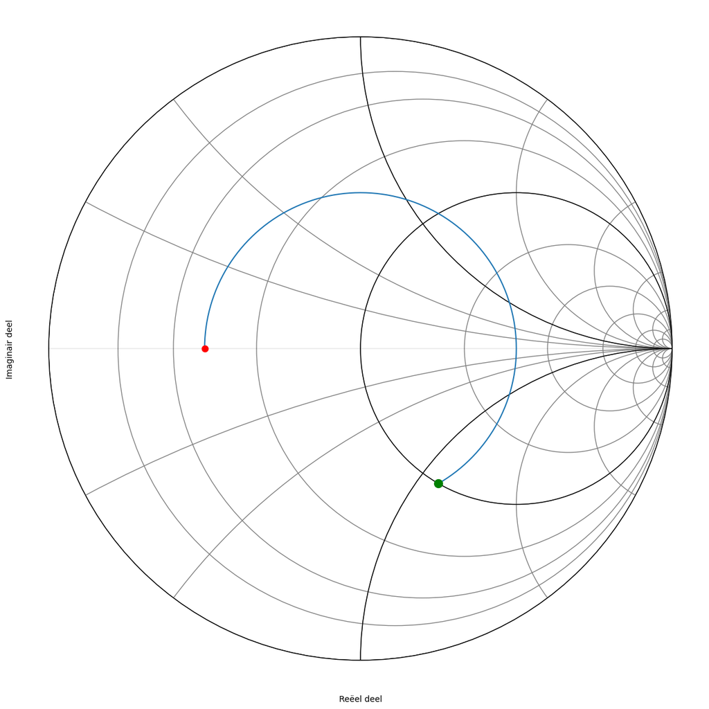

###### detail van het verloop van de admittantie

```
hoek    admittantie (Siemens)     lengte coax (cm)
 237    Y= 21.27-23.78j mS     lengte=8.23 cm
 238    Y= 20.83-23.55j mS     lengte=8.26 cm
 239    Y= 20.41-23.33j mS     lengte=8.30 cm
 240    Y= 20.00-23.09j mS     lengte=8.33 cm
 241    Y= 19.60-22.86j mS     lengte=8.37 cm
 242    Y= 19.22-22.62j mS     lengte=8.40 cm
```

###### Circuit van de derde oplossing

[figure not shown]

###### Smith kaart van de vierde oplossing: L in parallel

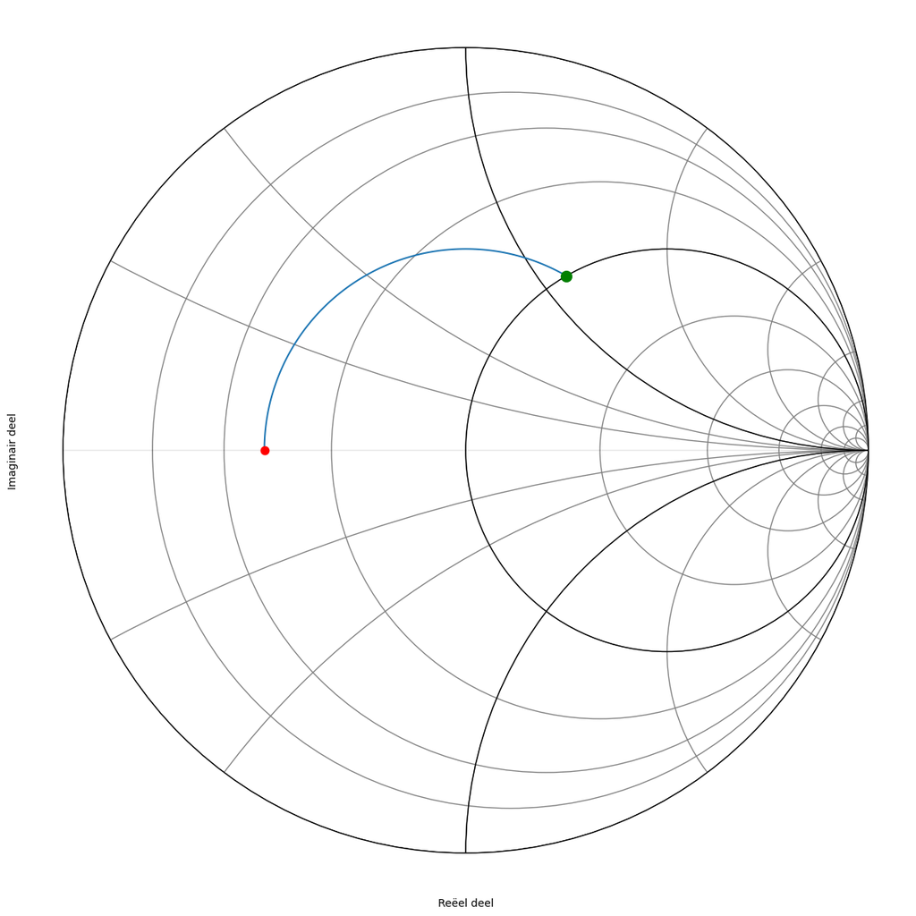

###### detail van het verloop van de admittantie

```
hoek    admittantie (Siemens)     lengte coax (cm)
 118    Y= 19.22+22.62j mS     lengte=4.10 cm
 119    Y= 19.60+22.86j mS     lengte=4.13 cm
 120    Y= 20.00+23.09j mS     lengte=4.17 cm
 121    Y= 20.41+23.33j mS     lengte=4.20 cm
```

Het schema dat we nodig hebben om deze vierde oplossing te realiseren wordt dus:

###### Circuit van de vierde oplossing

[figure not shown]

###### Smith kaart van de vijfde oplossing: C=> open lijn

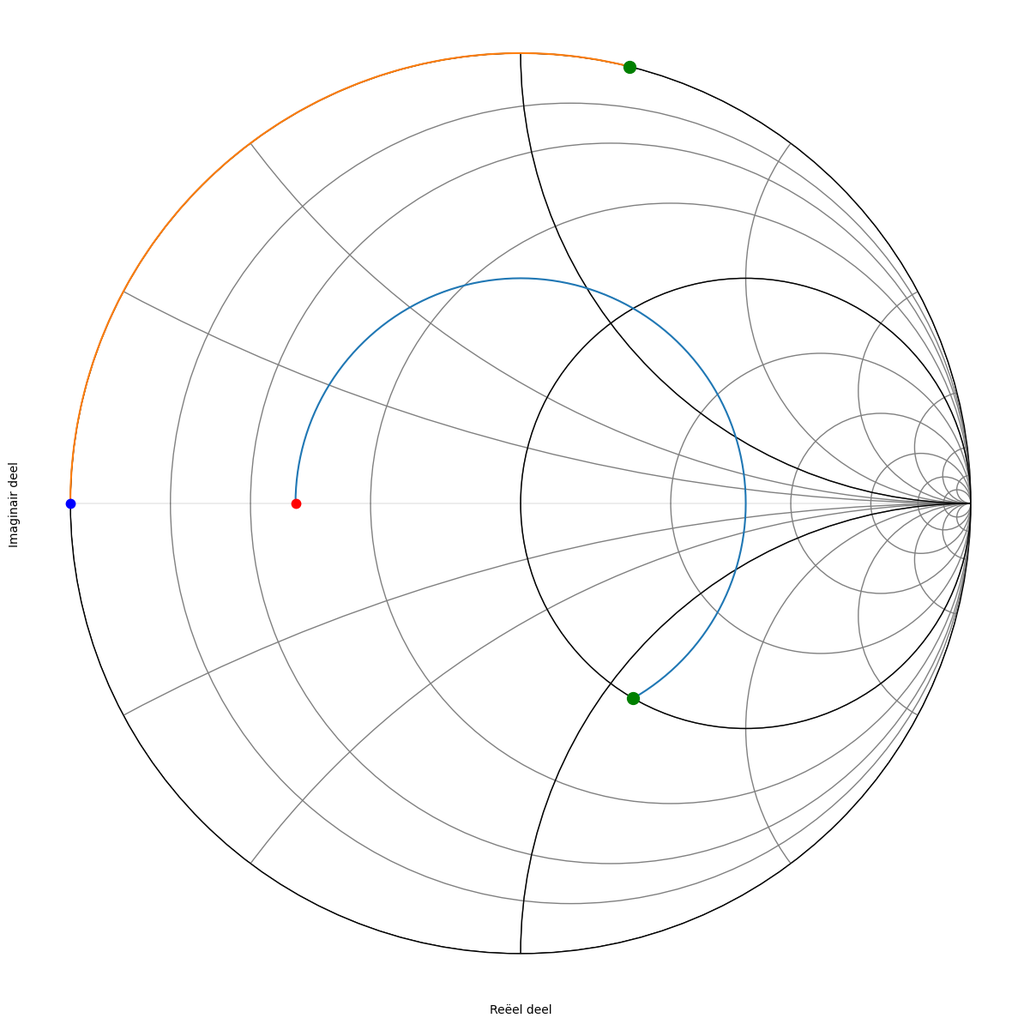

###### detail van het verloop van de admittantie

```
hoek    admittantie (Siemens)     lengte coax (cm)
 238    Y= 20.83-23.55j mS     lengte=8.26 cm
 239    Y= 20.41-23.33j mS     lengte=8.30 cm
 240    Y= 20.00-23.09j mS     lengte=8.33 cm
 241    Y= 19.60-22.86j mS     lengte=8.37 cm
```

###### detail van het verloop van de admittantie open lijn

```
hoek    admittantie (Siemens)     lengte coax (cm)
  95       Y= +21.83j mS     lengte=3.30 cm
  96       Y= +22.21j mS     lengte=3.33 cm
  97       Y= +22.61j mS     lengte=3.37 cm
  98       Y= +23.01j mS     lengte=3.40 cm
  99       Y= +23.42j mS     lengte=3.44 cm
 100       Y= +23.84j mS     lengte=3.47 cm
```

Hieruit blijkt dat een open transmissielijn met de lengte van $\frac{98}{360} \frac{\lambda}{2}$ de beste aanpassing geeft.

Het stukje open coax dat we moeten voorzien ter vervanging van de condensator is dus: 3.4 cm

Het schema dat we nodig hebben om deze vijfde oplossing te realiseren wordt dus:

###### Circuit van de vijfde oplossing

[figure not shown]

###### Smith kaart van de zesde oplossing: C => kortgesloten lijn

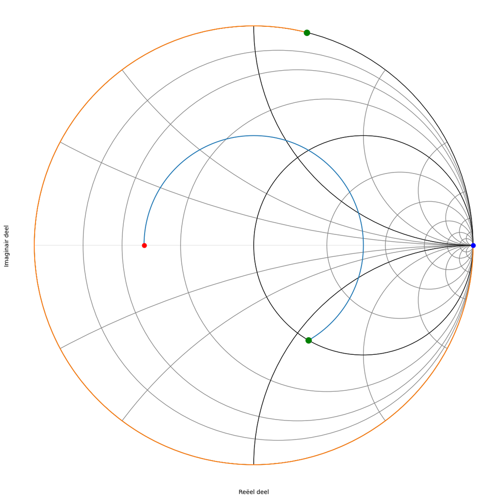

###### detail van het verloop van de admittantie

```
hoek    admittantie (Siemens)     lengte coax (cm)
 238    Y= 20.83-23.55j mS     lengte=8.26 cm
 239    Y= 20.41-23.33j mS     lengte=8.30 cm
 240    Y= 20.00-23.09j mS     lengte=8.33 cm
 241    Y= 19.60-22.86j mS     lengte=8.37 cm
```

```
hoek    admittantie (Siemens)     lengte coax (cm)
 275       Y= +21.83j mS     lengte=9.55 cm
 276       Y= +22.21j mS     lengte=9.58 cm
 277       Y= +22.61j mS     lengte=9.62 cm
 278       Y= +23.01j mS     lengte=9.65 cm
 279       Y= +23.42j mS     lengte=9.69 cm
 280       Y= +23.84j mS     lengte=9.72 cm
```

Het stukje kortgesloten coax dat we moeten voorzien ter vervanging van de condensator is dus: 9.7 cm

Het schema dat we nodig hebben om deze zesde oplossing te realiseren wordt dus:

###### Circuit van de zesde oplossing

[figure not shown]

### Oplossing 7: Oplossing 4 waarbij het spoel vervangen is door een open transmissielijn

De y = 1 + j 1.15 compenseren we door -j 1.15 vertrekkende vanuit g=0.

###### Smith kaart van de zevende oplossing: L => open lijn

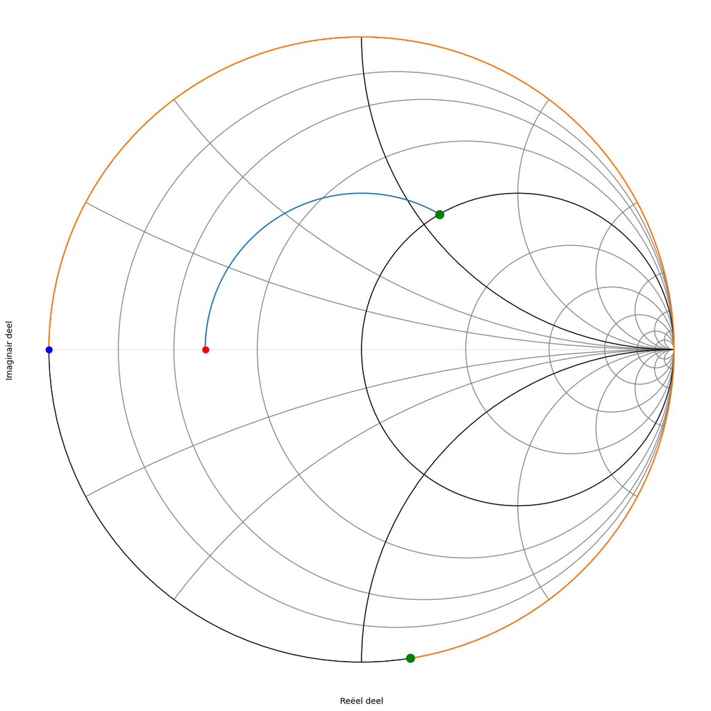

###### detail van het verloop van de admittantie

```
hoek    admittantie (Siemens)     lengte coax (cm)
 118    Y= 19.22+22.62j mS     lengte=4.10 cm
 119    Y= 19.60+22.86j mS     lengte=4.13 cm
 120    Y= 20.00+23.09j mS     lengte=4.17 cm
 121    Y= 20.41+23.33j mS     lengte=4.20 cm
```

###### detail van het verloop van de admittantie open lijn

```
hoek    admittantie (Siemens)     lengte coax (cm)
 260       Y= -23.84j mS     lengte=9.03 cm
 261       Y= -23.42j mS     lengte=9.06 cm
 262       Y= -23.01j mS     lengte=9.10 cm
 263       Y= -22.61j mS     lengte=9.13 cm
 264       Y= -22.21j mS     lengte=9.17 cm
```

Het schema dat we nodig hebben om deze zevende oplossing te realiseren wordt dus:

###### Circuit van de zevende oplossing

[figure not shown]

###### Smith kaart van de achtste oplossing: L => kortgesloten lijn

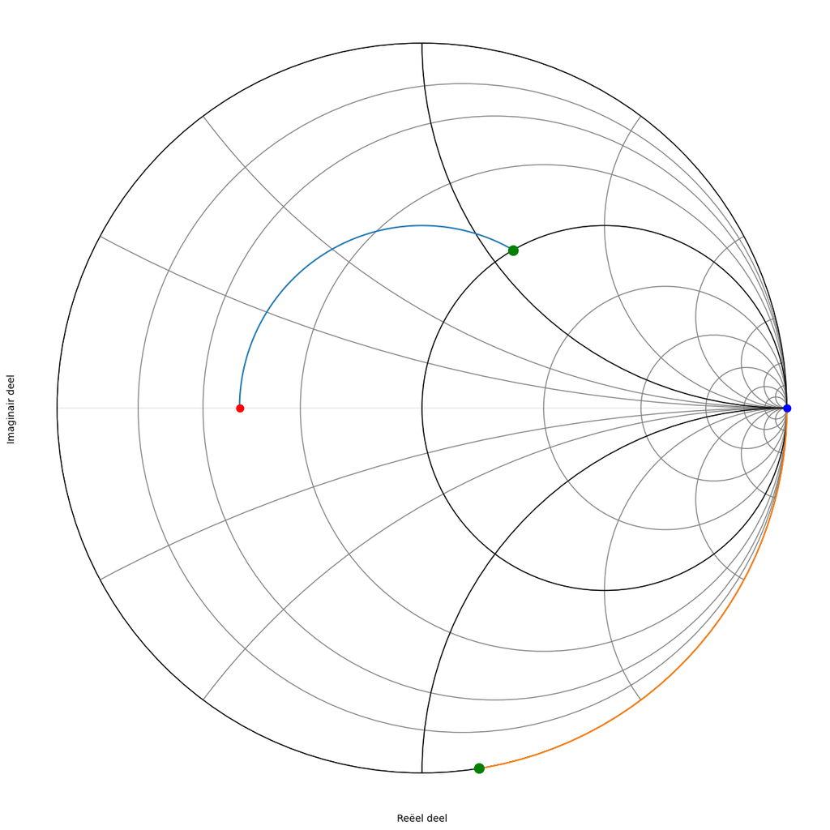

###### detail van het verloop van de admittantie

```
hoek    admittantie (Siemens)     lengte coax (cm)
 118    Y= 19.22+22.62j mS     lengte=4.10 cm
 119    Y= 19.60+22.86j mS     lengte=4.13 cm
 120    Y= 20.00+23.09j mS     lengte=4.17 cm
 121    Y= 20.41+23.33j mS     lengte=4.20 cm
```

```
hoek    admittantie (Siemens)     lengte coax (cm)
  80       Y= -23.84j mS     lengte=2.78 cm
  81       Y= -23.42j mS     lengte=2.81 cm
  82       Y= -23.01j mS     lengte=2.85 cm
  83       Y= -22.61j mS     lengte=2.88 cm
  84       Y= -22.21j mS     lengte=2.92 cm
```

Overzicht van de bekomen admittantie als functie van de hoek op de Smith kaart. De laatste kolom geeft de nodige lengte van de coax

###### Circuit van de achtste oplossing

[figure not shown]

I would rather have questions that can't be answered  
than answers that can't be questioned.

Richard Feynman